# openFDA exploratory analysis

Mary T-M

February 2016

We begin by grouping by manufacturer after cleaning up the strings. Baxter and Medtronic appear to be outliers but they are also large companies so it may simply be a function of market share.

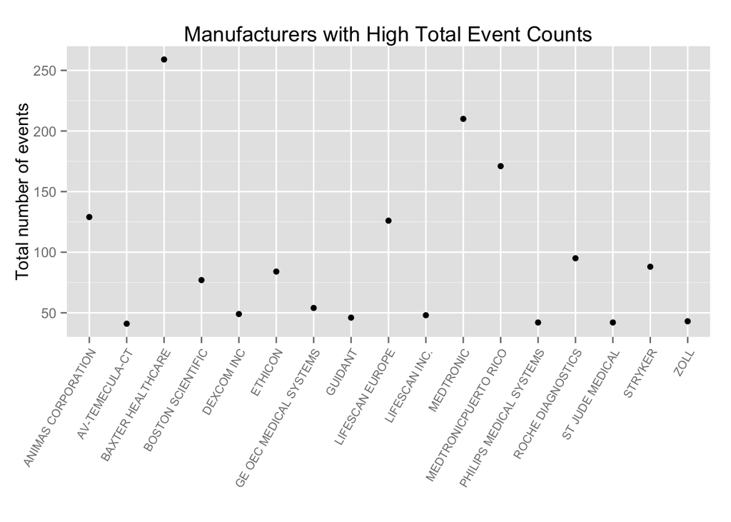

The average total count for each event type in each device class is low but there are many outliers–note this chart is on a log scale

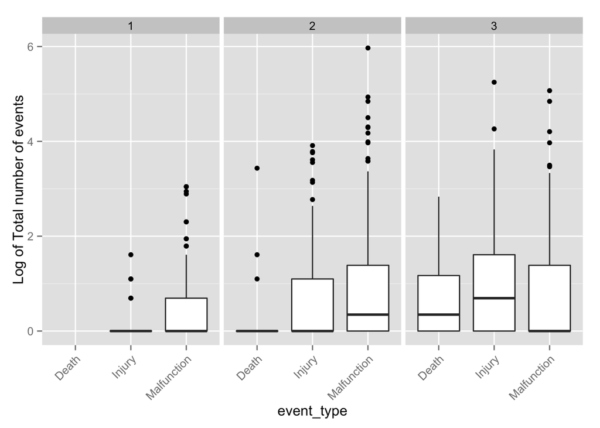

Grouping by manufacturer and plotting those with a total of all events greater than 40 or any deaths at all. It seems that a large number of injuries or malfunctions does not necessarily imply a proportional number of deaths.

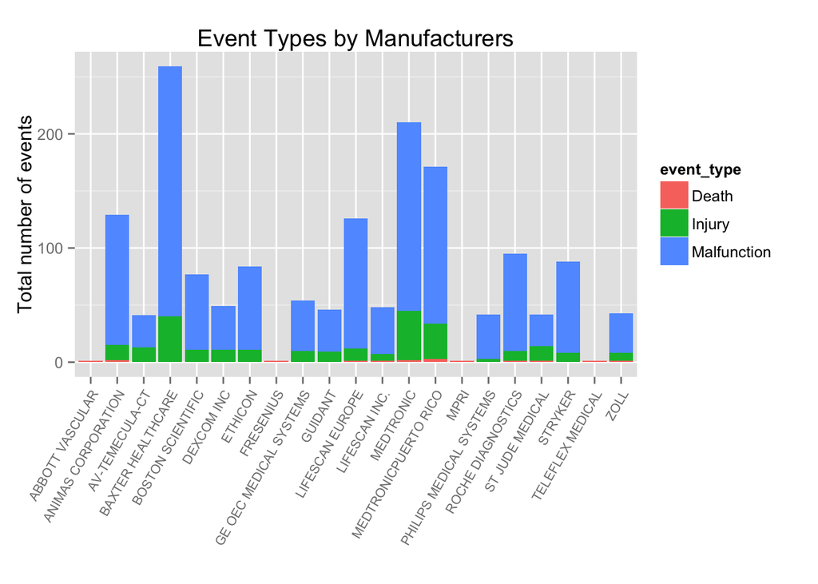

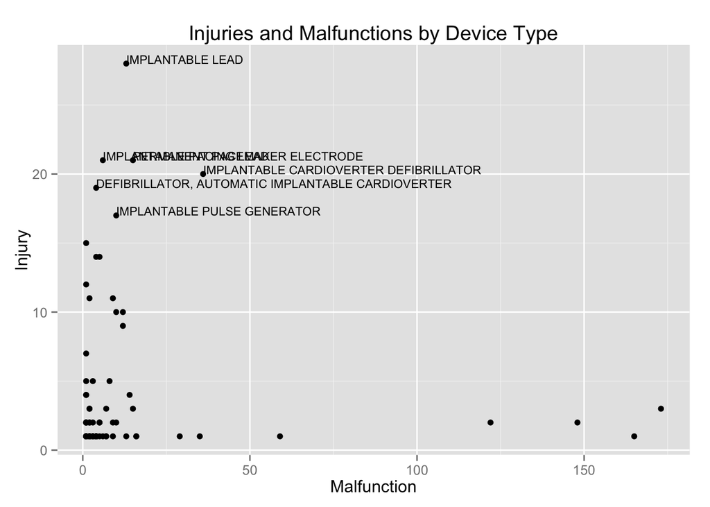

Two further examples of an item with many malfunctions, few injuries and vice versa, again this makes intuitive sense.

```r
example <- arrange(ungroup(filterthere), Malfunction)

glucose <- subset(example, grepl("BLOOD GLUCOSE", example$generic_name))
colSums(glucose[2:4])
```

```
##       Death      Injury Malfunction
##          NA           2          51
```

```r
defibs <- subset(example, grepl("CARDIAC", example$generic_name))
colSums(defibs[2:4])
```

```
##       Death      Injury Malfunction
##          NA          13           4
```

Looking at the adverse event flag helps distinguish which malfunctions are serious.

```
## , , class = 1
##
##                     adverse_event_flag
## event_type                   N    Y
##   Death                 0    0    0
##   Injury                0    4   45
##   Malfunction           4  241    4
##   No answer provided    0   20    3
##   Other                 0   10    7
##
## , , class = 2
##
##                     adverse_event_flag
## event_type                   N    Y
##   Death                 0    1   58
##   Injury                1   50  666
##   Malfunction           3 1925   28
##   No answer provided    0   24    6
##   Other                 0   16   41
##
## , , class = 3
##
##                     adverse_event_flag
## event_type                   N    Y
##   Death                 0    4   55
##   Injury                1   66  846
##   Malfunction           0  682   72
##   No answer provided    0    7    7
##   Other                 0   10   20
```

Here showing the proportions of events that are serious for each class. They increase as expected as class 3 is the highest-risk class.

```
## Source: local data frame [3 x 4]
##
##    class total num_adverse      prop
##   (fctr) (int)       (int)     (dbl)
## 1      1   338          59 0.1745562
## 2      2  2819         799 0.2834338
## 3      3  1770        1000 0.5649718
```

There are more malfunctions in class 2, and more injuries in class 3. Are there devices on the edge of being classified in one class versus the other, and given the enhanced requirements for the higher class are manufacturers lobbying for this? Exemptions and other data may illuminate the transition between the two classes.

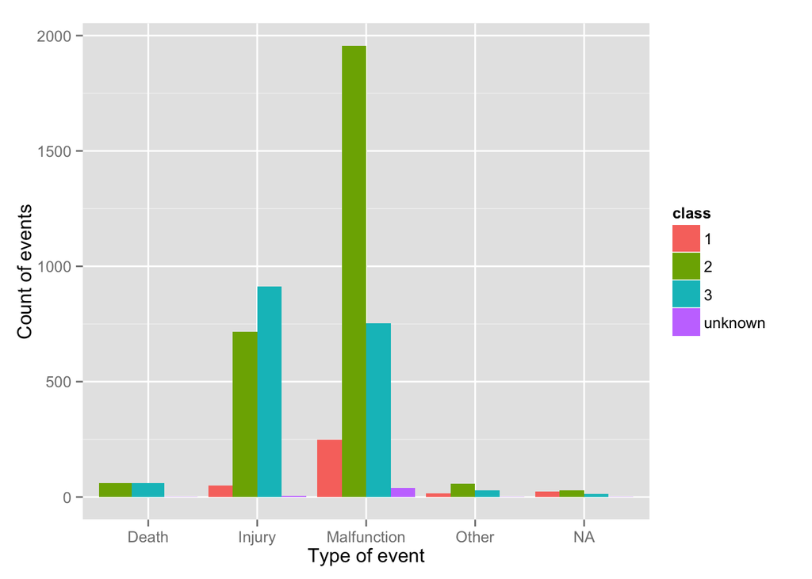

Here looking at which specialties have the highest number of each event type. Are certain panels more likely to approve dangerous devices?

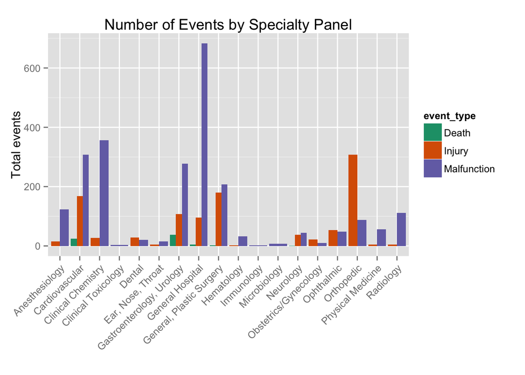